# ADS_project1_yz3006

Yi Zhang ; yz3006

9/29/2017

Every four years people witness the U.S. presidential inauguration. It always leads to wide discussion since the speeches are related to what the president would put emphasis in four years. Thus, exploring the speeches of all the U.S. presidents is becoming a popular topic. Using basic text mining and nlp process, I get some results shown as below.

```r
library("tm")
library("wordcloud")
library("RColorBrewer")
library("dplyr")
library("tidytext")
library("rvest")
library("tibble")
library("qdap")
library("sentimentr")
library("gplots")
library("dplyr")
library("syuzhet")
library("factoextra")
library("beeswarm")
library("scales")
library("RANN")
library("tm")
library("topicmodels")
library("xlsx")

source("/Users/YIZHANG/Desktop/fall2017-Project1-kellychang1994-master/lib/plotstacked.R")
source("/Users/YIZHANG/Desktop/fall2017-Project1-kellychang1994-master/lib/speechFuncs.R")
```

Firstly show the WordCloud for overall speeches and indivisual speeches respectively.

```r
folder.path = '/Users/YIZHANG/Desktop/fall2017-Project1-kellychang1994-master/data/InauguralSpeeches'
speeches=list.files(path = folder.path, pattern = "*.txt")
prex.out=substr(speeches, 6, nchar(speeches)-4)
```

```r
ff.all<-Corpus(DirSource(folder.path))
ff.all<-tm_map(ff.all, stripWhitespace) #delete extra white space
ff.all<-tm_map(ff.all, content_transformer(tolower)) #convert upper-case to lower-case
ff.all<-tm_map(ff.all, removeWords, stopwords("english")) # remove filler words
ff.all<-tm_map(ff.all, removeWords, character(0)) # remove empty strings
ff.all<-tm_map(ff.all, removePunctuation) # remove punctuation
tdm.all<-TermDocumentMatrix(ff.all)
tdm.tidy=tidy(tdm.all) # a dataframe with three variables: term, document, and count
tdm.overall=summarise(group_by(tdm.tidy, term), sum(count)) # a dataframe with two variables: term and count
```

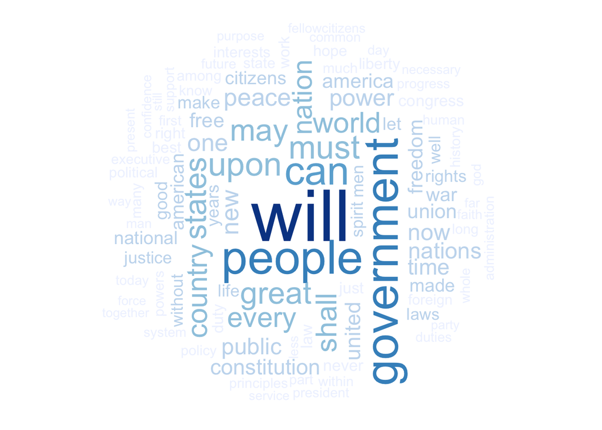

```r
wordcloud(tdm.overall$term, tdm.overall$`sum(count)`,
          scale=c(5,0.5),
          max.words=100,
          min.freq=1,
          random.order=FALSE,
          rot.per=0.3,
          use.r.layout=T,
          random.color=FALSE,
          colors=brewer.pal(7,"Blues")
          )
```

As is shown in the plot, “will”, “government” and “people” are top 3 frequently used words in presidential inauguration speeches. Then let we plot wordcloud for two parties to see if there is any difference in frenquency of word.

```r
data = read.xlsx("/Users/YIZHANG/Desktop/fall2017-Project1-kellychang1994-master/data/InaugurationInfo.xlsx", sheetIndex = 1)
CorpusTo = lapply(ff.all, scan_tokenizer)
Df = data.frame(text = sapply(CorpusTo, paste, collapse = " "), stringsAsFactors = FALSE)
Df = cbind(data,Df)
Df[] = lapply(Df, as.character)
#For DEMOCRATIC
demo=Df$text[nrow(Df)]
for (i in seq(nrow(Df)))
{
  if(is.na(Df$Party[i]))
  {
    Df$Party[i]="NP"
  }

  if((Df$Party[i]=="Democratic"))
  {
    temp=Df$text[i]
    demo=rbind(demo,temp)
  }
}


#For REPUBLICAN
repub=Df$text[nrow(Df)]
for (i in seq(nrow(Df)))
{
  if(is.na(Df$Party[i]))
  {
    Df$Party[i]="NP"
  }

  if((Df$Party[i]=="Republican"))
  {
    temp=Df$text[i]
    repub=rbind(repub,temp)
  }
}
```

```r
#Basic text mining as we did in the previous part in overall speeches
repub.corpus=Corpus(DataframeSource(repub))
demo.corpus=Corpus(DataframeSource(demo))
repub = tm_map(repub.corpus, stripWhitespace)
repub = tm_map(repub.corpus, content_transformer(tolower))
repub = tm_map(repub.corpus, removeWords, stopwords("english"))
repub = tm_map(repub.corpus, removeWords, character(0))
repub = tm_map(repub.corpus, removePunctuation)
demo = tm_map(demo.corpus, stripWhitespace)
demo = tm_map(demo.corpus, content_transformer(tolower))
demo = tm_map(demo.corpus, removeWords, stopwords("english"))
demo = tm_map(demo.corpus, removeWords, character(0))
demo = tm_map(demo.corpus, removePunctuation)
tdm.repub<-TermDocumentMatrix(repub)
tdm.demo<-TermDocumentMatrix(demo)
tdm.tidy.repub = tidy(tdm.repub)
tdm.tidy.demo = tidy(tdm.demo)
tdm.overall.repub=summarise(group_by(tdm.tidy.repub, term), sum(count))
tdm.overall.demo=summarise(group_by(tdm.tidy.demo, term), sum(count))
```

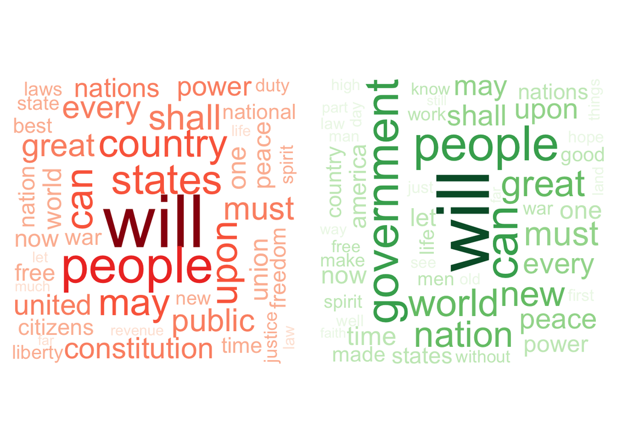

```r
par(mfrow=c(1,2))
wordcloud(tdm.overall.repub$term, tdm.overall.repub$`sum(count)`,
          scale=c(5,0.5),
          max.words=100,
          min.freq=1,
          random.order=FALSE,
          rot.per=0.3,
          use.r.layout=T,
          random.color=FALSE,
          colors=brewer.pal(7,"Reds"),
          title = 'WordCloud-Republican party')

wordcloud(tdm.overall.demo$term, tdm.overall.demo$`sum(count)`,
          scale=c(5,0.5),
          max.words=100,
          min.freq=1,
          random.order=FALSE,
          rot.per=0.3,
          use.r.layout=T,
          random.color=FALSE,
          colors=brewer.pal(7,"Greens"),
          title = 'WordCloud-Democratic party')
```

It looks like apart from the most frequently words in overall speeches the Republican use a lot “country”, “shall”, “public”, “may”, and etc. While the Democratic is more likely to put in the speeches “new”, “must”, “every”, “can”, “peace”, and etc.

Then we use sentiment analysis to explore more about the texts.

```r
setwd("/Users/YIZHANG/Desktop/fall2017-Project1-kellychang1994-master/data/InauguralSpeeches")
data = read.xlsx("/Users/YIZHANG/Desktop/fall2017-Project1-kellychang1994-master/data/InaugurationInfo.xlsx", sheetIndex= 1)
ups = unique(data$File)
files = paste0("inaug",paste(data$File, data$Term, sep = "-"),".txt")
speech.list = NULL
for(i in 1:length(files)){
  sp = paste(readLines(files[i],n=-1, skipNul=TRUE),collapse=" ")
  speech.list  = c(speech.list, sp)
}
speech.list = data.frame(fulltext = speech.list)
```

```r
sentence.list=NULL
for(i in 1:nrow(speech.list)){
  sentences=sent_detect(speech.list$fulltext[i],
                        endmarks = c("?", ".", "!", "|",";"))
  if(length(sentences)>0){
    emotions=get_nrc_sentiment(sentences)
    word.count=word_count(sentences)
    emotions=diag(1/(word.count+0.01))%*%as.matrix(emotions)
    sentence.list=rbind(sentence.list,
                        cbind(speech.list[i,-ncol(speech.list)],
                              sentences=as.character(sentences),
                              word.count,
                              emotions,
                              sent.id=1:length(sentences), File = data$File[i],
                              Term = data$Term[i]
                        )
    )
  }
}
# some non-sentences exist in raw data due to erroneous extra end-of sentence marks
sentence.list=
  sentence.list%>%
  filter(!is.na(word.count))
```

Choosing a list of famous presidents or presidents candidates, we analyse their sentences in the speeches in some simple visualization.

```r
sel.comparison=c("DonaldJTrump","JohnMcCain", "GeorgeBush", "MittRomney", "GeorgeWBush", "RonaldReagan","AlbertGore,Jr","HillaryClinton","JohnFKerry", "WilliamJClinton","HarrySTruman", "BarackObama", "LyndonBJohnson","GeraldRFord", "JimmyCarter", "DwightDEisenhower", "FranklinDRoosevelt","HerbertHoover","JohnFKennedy","RichardNixon","WoodrowWilson","AbrahamLincoln", "TheodoreRoosevelt", "JamesGarfield","JohnQuincyAdams", "UlyssesSGrant", "ThomasJefferson", "GeorgeWashington", "WilliamHowardTaft", "AndrewJackson","WilliamHenryHarrison", "JohnAdams")
```

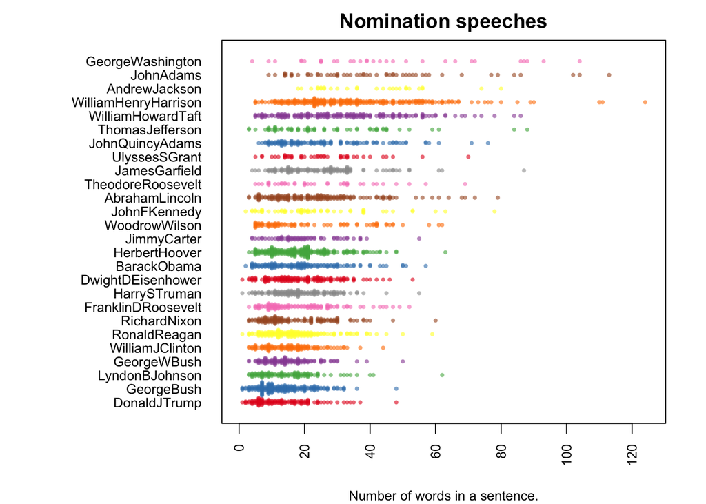

```r
par(mar=c(4, 11, 2, 2))
pos = which(sentence.list$Term==1 & sentence.list$File%in%sel.comparison)
#sel.comparison=levels(sentence.list$FileOrdered)
sentence.list.sel= sentence.list[pos,]
sentence.list.sel$File= factor(sentence.list.sel$File)

sentence.list.sel$FileOrdered=reorder(sentence.list.sel$File,
                                      sentence.list.sel$word.count,
                                      mean,
                                      order=T)


beeswarm(word.count~FileOrdered,
         data=sentence.list.sel,
         horizontal = TRUE,
         pch=16, col=alpha(brewer.pal(9, "Set1"), 0.6),
         cex=0.55, cex.axis=0.8, cex.lab=0.8,
         spacing=5/nlevels(sentence.list.sel$FileOrdered),
         las=2, xlab="Number of words in a sentence.", ylab="",
         main="Nomination speeches")
```

Next we compare the length of sentences in Obama and Trump inauguration.

```r
sentence.list %>%
  filter(File == 'DonaldJTrump',
         word.count <= 3) %>%
  select(sentences)
```

```
##            sentences
## 1         Thank you.
## 2                 C.
## 3         Thank you.
## 4     God bless you.
## 5         Thank you.
## 6 God bless America.
```

```r
sentence.list %>%
  filter(File == 'BarackObama',
         word.count <= 3) %>%
  select(sentences)
```

```
##                 sentences
## 1              Thank you.
## 2              Thank you.
## 3 diversity and openness;
## 4              Thank you.
```

It presents simple and informal sentence in speeches for both of them. Now we look at the emotions reflected by their speeches.

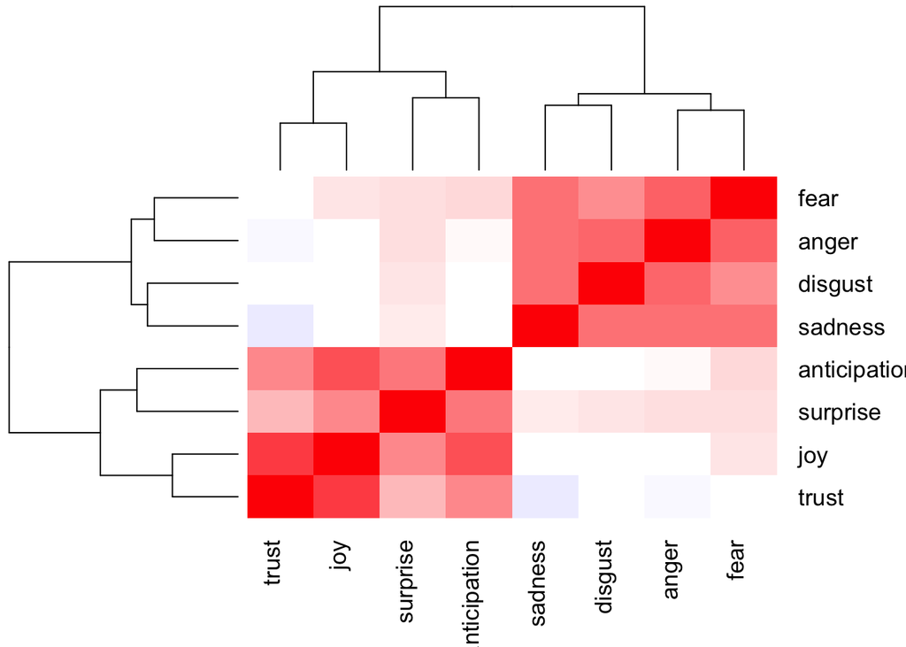

```r
# Clustering of Emotions for All Speeches
heatmap.2(cor(sentence.list%>%select(anger:trust)),
          scale = "none",
          col = bluered(100),  margin=c(6, 6), key=F,
          trace = "none", density.info = "none")
```

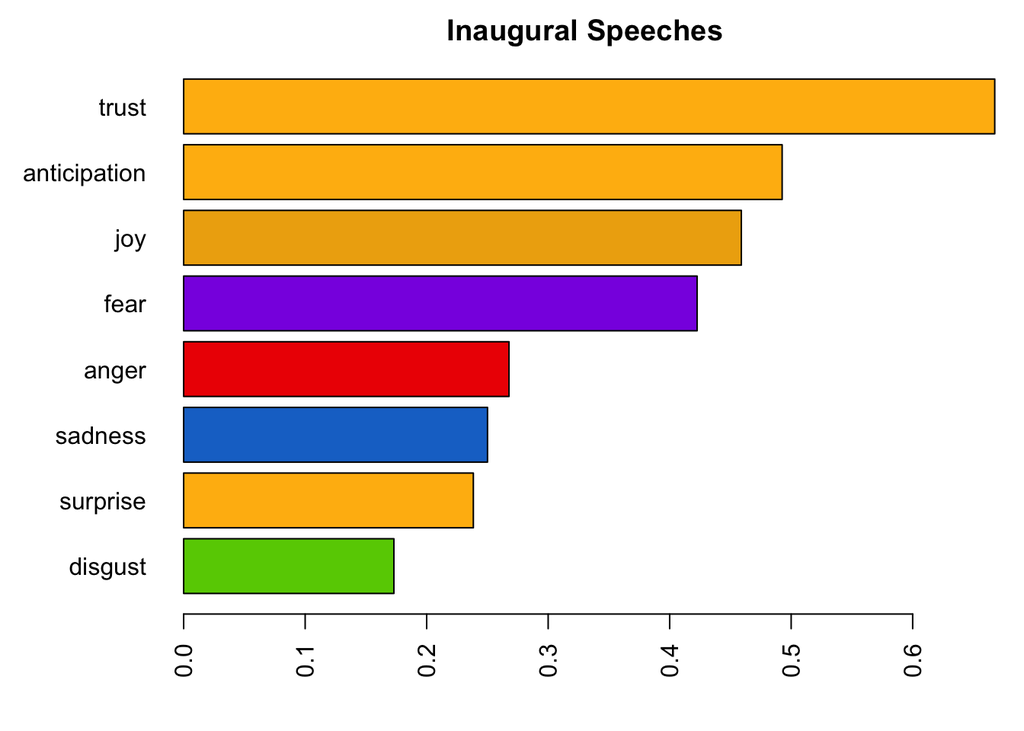

```r
#make barplot for the average value of clustering emotions
par(mar=c(4, 6, 2, 1))
emo.means=colMeans(select(sentence.list, anger:trust)>0.01)
col.use=c("red2", "darkgoldenrod1",
          "chartreuse3", "blueviolet",
          "darkgoldenrod2", "dodgerblue3",
          "darkgoldenrod1", "darkgoldenrod1")
barplot(emo.means[order(emo.means)], las=2, col=col.use[order(emo.means)], horiz=T, main="Inaugural Speeches")
```

It is shown that presidents have tendency to pass positive words to the audience and hence they could get more support in return. Let us look at the example of Trump and Obama.

```r
# Sentences with emotions for Trump and Obama
speech.df = tbl_df(sentence.list) %>%
  filter(File == 'DonaldJTrump', word.count >= 4) %>%
  select(sentences, anger:trust)
speech.df = as.data.frame(speech.df)
as.character(speech.df$sentences[apply(speech.df[,-1], 2, which.max)])
```

```
## [1] "There should be no fear."
## [2] "And God bless America."
## [3] "America will start winning again, winning like never before."
## [4] "And God bless America."
## [5] "And God bless America."
## [6] "America will start winning again, winning like never before."
## [7] "They have been magnificent."
## [8] "And God bless America."
```

```r
print('Barack Obama')
```

```
## [1] "Barack Obama"
```

```r
speech.df = tbl_df(sentence.list) %>%
  filter(File == 'BarackObama', word.count >= 4) %>%
  select(sentences, anger:trust)
speech.df = as.data.frame(speech.df)
as.character(speech.df$sentences[apply(speech.df[,-1], 2, which.max)])
```

```
## [1] "The Capital was abandoned."
## [2] "This is the journey we continue today."
## [3] "Our capacity remains undiminished."
## [4] "Our capacity remains undiminished."
## [5] "when the wages of honest labor liberate families from the brink of hardship."
## [6] "The Capital was abandoned."
## [7] "when the wages of honest labor liberate families from the brink of hardship."
## [8] "We affirm the promise of our democracy."
```

The difference in the two examples is that Trump seems to repeat some sentences which may reflect what he would expect America to be, such as winnning again and being more powerful; however, Obama is more likely to put sentences containing like “capital”, “wages” and “labor”. Then we explore the clustering emotions among all speeches by 5 groups.

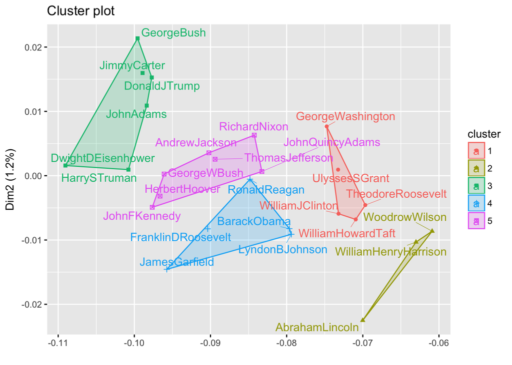

```r
presid.summary=tbl_df(sentence.list)%>%
  subset(File%in%sel.comparison)%>%
  group_by(File)%>%
  summarise(
    anger=mean(anger),
    anticipation=mean(anticipation),
    disgust=mean(disgust),
    fear=mean(fear),
    joy=mean(joy),
    sadness=mean(sadness),
    surprise=mean(surprise),
    trust=mean(trust)
  )
presid.summary=as.data.frame(presid.summary)
rownames(presid.summary)=as.character((presid.summary[,1]))

# Perform k-means clustering on emotions data frame
km.res=kmeans(presid.summary[,-1], iter.max=200,
              5)
fviz_cluster(km.res,
             stand=F, repel= TRUE,
             data = presid.summary[,-1], xlab="", xaxt="n",
             show.clust.cent=FALSE)
```